# Virginia Election Code Walkthrough

Author

Katie Coolidge

1 Intro: Here I will be using Virginia election data from the race between Biden and Trump but also the race for Governor between Terry McAuliffe and Glenn Youngkin.

We will use the data throughout this walkthrough to show several comparisons between candidates of each race.

2. Here we will be making a broad datatable from the election information so that you can search through and play with the different arguments.

First I took my dataset with all the information, joined_vacomparison and made a searchable data table by using DT::datatable function and making sure I put in a filter argument = “top” to let a viewer search by the top labels.

```r
joined_vacomparison %>%
  DT::datatable(rownames = FALSE, filter = "top",
                options = list(searching = FALSE, paging = FALSE, dom = "tip"))
```

| locality | biden | trump | biden_pct | trump_pct | youngkin | mcauliffe | pct_youngkin | pct_mcauliffe |
| --- | --- | --- | --- | --- | --- | --- | --- | --- |
| ACCOMACK COUNTY | 7578 | 9172 | 44.68 | 54.07 | 7878 | 4948 | 61.08 | 38.37 |
| ALBEMARLE COUNTY | 42466 | 20804 | 65.68 | 32.18 | 19141 | 31919 | 37.21 | 62.05 |
| ALEXANDRIA CITY | 66240 | 14544 | 80.28 | 17.63 | 14013 | 43866 | 24.02 | 75.2 |
| ALLEGHANY COUNTY | 2243 | 5859 | 27.34 | 71.43 | 4530 | 1518 | 74.52 | 24.97 |
| AMELIA COUNTY | 2411 | 5390 | 30.55 | 68.29 | 4720 | 1617 | 74.19 | 25.42 |
| AMHERST COUNTY | 5672 | 11041 | 33.35 | 64.93 | 9731 | 3897 | 71 | 28.43 |
| APPOMATTOX COUNTY | 2418 | 6702 | 26.09 | 72.31 | 5971 | 1438 | 80.26 | 19.33 |
| ARLINGTON COUNTY | 105344 | 22318 | 80.6 | 17.08 | 21548 | 73013 | 22.63 | 76.67 |
| AUGUSTA COUNTY | 10840 | 30714 | 25.64 | 72.65 | 26196 | 7231 | 77.93 | 21.51 |
| BATH COUNTY | 646 | 1834 | 25.83 | 73.33 | 1539 | 396 | 79.04 | 20.34 |

[output cut: 123 more lines]

3 & 4: Ultimately, this code will show us a chart of the top 5 counties with the highest differences between Youngkin and Trump percentages.

To do this, first I had to make a new column to calculate the difference between the percentage of the Youngkin vote and Trump vote by using mutate(), picking a name for the column, Rgov_to_pres and giving them the calculation, pct_youngkin - trump_pct. Then I arranged this data in descending order (greatest to least).

Now, I only want the top 5. I made a new dataset called top_5_counties_youngkin_v_trump to cut off my original dataset Rgov_to_pres_joined_vacomparison to only 5 values by using head().

Then to create the chart I used ggplot() and picked the new data set I created of just the top 5 counties, top_5_counties_youngkin_v_trump and made sure to reorder my input so that the y values would be in the first quadrant and not negative numbers. I wanted x=locality and y = the values from the new column we made calculating the difference in percent between youngkin and trump. Therefore, x = reorder(locality, -Rgov_to_pres, y = Rgov_to_pres).

Then I used geom(col) to make the bar chart to show it.

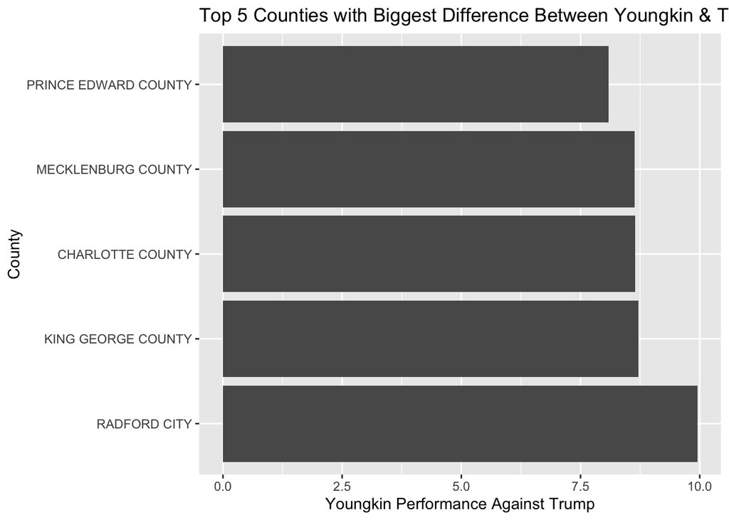

```r
Rgov_to_pres_joined_vacomparison <- joined_vacomparison %>%
mutate(Rgov_to_pres = pct_youngkin - trump_pct) %>%
  arrange(desc(Rgov_to_pres))

top_5_counties_youngkin_v_trump <- head(Rgov_to_pres_joined_vacomparison,5)

ggplot(top_5_counties_youngkin_v_trump, aes(x = reorder(locality, -Rgov_to_pres), y = Rgov_to_pres)) +
  coord_flip() +
    scale_y_continuous(name = "Youngkin Performance Against Trump", labels = scales::comma) +
  scale_x_discrete(name = "County") +
  labs(title = "Top 5 Counties with Biggest Difference Between Youngkin & Trump") +
  geom_col()
```

5. Here I wanted to create a chart that shows the top 5 counties where Youngkin got the highest percentage of the vote.

To do this first I made a new dataset named top_5_youngkin_counties by only including the two columns I needed – locality and the percent of youngkins vote select(locality, pct_youngkin). Then, I arranged these values in descending order with arrange(desc()) and only took the top 5 by using head(5).

In order to make a bar chart of the top 5 results I had to use ggplot() to select the new dataset, top_5_youngkin_counties. I needed to reorder the x so that my y values would show up cleanly so I used locality for my x value and the percent of youngkin votes as the y “pct_youngkin”.

Then, I used geom_col() to make the bar chart of the data.

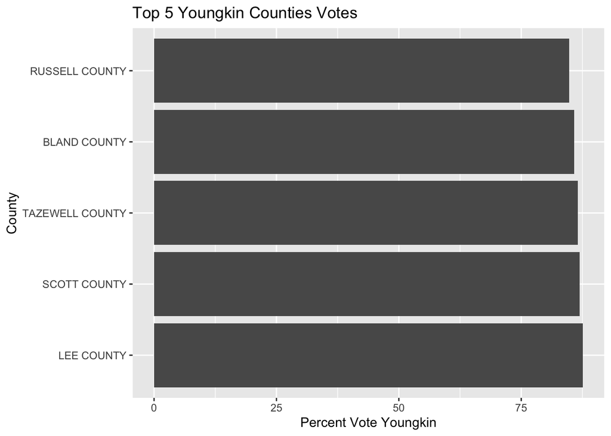

```r
top_5_youngkin_counties <- joined_vacomparison %>%
  select(locality, pct_youngkin) %>%
   arrange(desc(pct_youngkin)) %>%
  head(5)

ggplot(top_5_youngkin_counties, aes(x = reorder(locality, -pct_youngkin), y = pct_youngkin)) +
    coord_flip() +
  scale_y_continuous(name = "Percent Vote Youngkin", labels = scales::comma) +
  scale_x_discrete(name = "County") +
  labs(title = "Top 5 Youngkin Counties Votes") +
  geom_col()
```

6. Here I wanted to create a TABLE that shows the top 5 counties where McAuliffe got the highest percent of the vote.

To do this first I made a new dataset names top_5_mcauliffe_counties from my original dataset joined_vacomparison. In the new dataset I selected only the two fields I needed which where locality and pct_mcauliffe. Then I arranged them in descending order by using arrange(desc(pct_mcauliffe)) and head(5) to only take the top 5.

From here I made my table using DT:: datatable and inputted the dataset I wanted to make a table which was top_5_mcauliffe_counties.

```r
top_5_mcauliffe_counties <- joined_vacomparison %>%
  select(locality, pct_mcauliffe) %>%
   arrange(desc(pct_mcauliffe)) %>%
  head(5)

DT::datatable(top_5_mcauliffe_counties)
```

|  | locality | pct_mcauliffe |
| --- | --- | --- |
| 1 | PETERSBURG CITY | 84.87 |
| 2 | CHARLOTTESVILLE CITY | 82.88 |
| 3 | RICHMOND CITY | 77.27 |
| 4 | FALLS CHURCH CITY | 76.69 |
| 5 | ARLINGTON COUNTY | 76.67 |

7. In this segment I wanted to compare the 2 candidates for governor.

First, I had to add a new column to joined_vacomparison to compare the percent vote of youngkin to mcauliffe. I did this by using the function mutate() and giving them the equation to find the difference = pct_youngkin - pct_mcauliffe.

Then I renamed the dataset to be more specific to gov_r_win_joined_vacomparison and arranged the new column that I created (gov_r_win) in descending order using arrange(desc(govr_r_win)). Then I only wanted the top 10 so I headed it, head(10).

In order to create the chart of this I used ggplot() and selected the dataset I needed – gov_r_win_joined_vacomparison, and then told ggplot what would be in my x and y axis, x = locality and y = gov_r_win. In order to format it nicely I used reorder to make sure my y values were in the first quadrant.

Then I used geom(col) to make the actual chart.

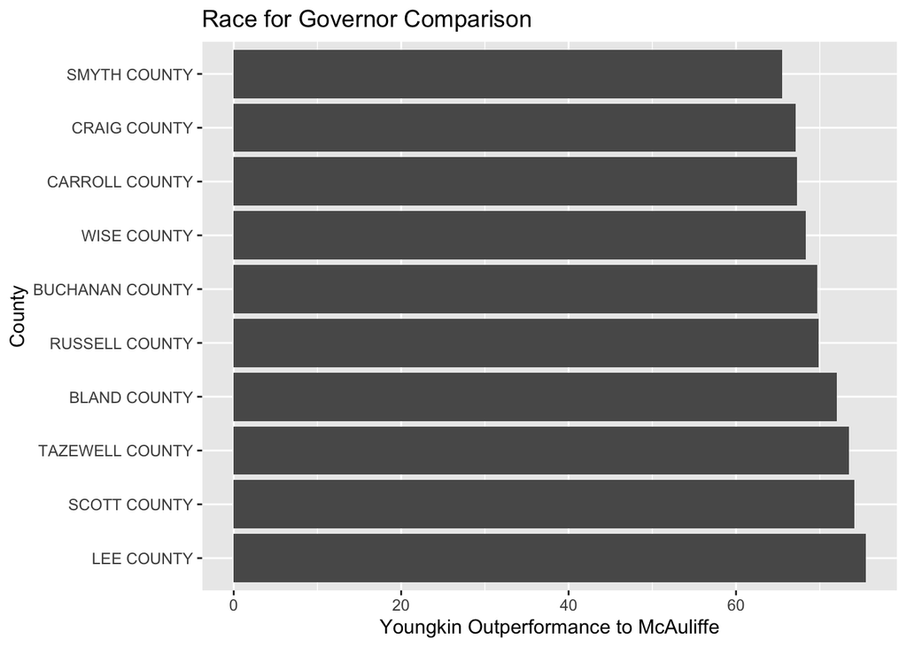

```r
#compares governor race R to D

joined_vacomparison <- joined_vacomparison %>%
mutate(gov_r_win = pct_youngkin - pct_mcauliffe)

gov_r_win_joined_vacomparison <- joined_vacomparison %>%
  arrange(desc(gov_r_win)) %>%
  head(10)


ggplot(gov_r_win_joined_vacomparison, aes(x = reorder(locality, -gov_r_win), y = gov_r_win)) +
    coord_flip() +
  scale_y_continuous(name = "Youngkin Outperformance to McAuliffe", labels = scales::comma) +
  scale_x_discrete(name = "County") +
  labs(title = "Race for Governor Comparison") +
  geom_col()
```

8. Here I wanted to compare the two democrat candidates for governor and presidency and see if the governor got more or less percent vote than the president did.

First I made a new column – d_gov_to_pres in order to show the difference between mcauliffe and biden by using mutate(pct_mcauliffe - biden_pct).

Then I named the dataset d_gov_to_pres_joined_vacomparison in order to arrange the values in descending order using arrange(desc(new column I made)). I only needed the locality field and the difference in pctent votes so I selected only those two fields. Then I only wanted the top 10 so I headed it at 10.

I made a datatable of my results by usinf the datatable function and putting in the dataset the information would come from – d_gov_to_pres_joined_vacomparison.

```r
joined_vacomparison <- joined_vacomparison %>%
mutate(d_gov_to_pres = pct_mcauliffe - biden_pct)

d_gov_to_pres_joined_vacomparison <- joined_vacomparison %>%
  arrange(desc(d_gov_to_pres)) %>%
  select(locality, d_gov_to_pres) %>%
  head(10)


DT::datatable(d_gov_to_pres_joined_vacomparison)
```

|  | locality | d_gov_to_pres |
| --- | --- | --- |
| 1 | BUCHANAN COUNTY | -0.889999999999999 |
| 2 | DICKENSON COUNTY | -1.18 |
| 3 | BLAND COUNTY | -1.56 |
| 4 | GRAYSON COUNTY | -1.85 |
| 5 | CARROLL COUNTY | -2.01 |
| 6 | RAPPAHANNOCK COUNTY | -2.13 |
| 7 | HIGHLAND COUNTY | -2.26 |
| 8 | ALLEGHANY COUNTY | -2.37 |
| 9 | NORTON CITY | -2.38 |
| 10 | ROCKBRIDGE COUNTY | -2.38 |

9. Lastly, I wanted a table that would show the top 5 counties that voted for Trump/ where Trump got the highest percentage of the vote.

To do this I made a new datatable named top_5_trump_counties from the original dataset. Then I selected only the fields I wanted which were the location – locality and the trump percent of votes – trump_pct. I then put them in descending order with arrange(desc(trump_pct)) and only took the top 5 by using head(5).

To make the table I just used the name of the dataset, used a pipe –> %>% and attached the datatable function.

```r
top_5_trump_counties <- joined_vacomparison %>%
  select(locality, trump_pct) %>%
   arrange(desc(trump_pct)) %>%
  head(5)

top_5_trump_counties %>%
  DT::datatable(rownames = FALSE, filter = "top",
                options = list(searching = FALSE, paging = FALSE, dom = "tip"))
```

| locality | trump_pct |
| --- | --- |
| LEE COUNTY | 84.1 |
| BUCHANAN COUNTY | 83.5 |
| BLAND COUNTY | 83.44 |
| SCOTT COUNTY | 83.38 |
| TAZEWELL COUNTY | 83.1 |